# MA-217 Final Project

Thomas Gillis

2024-05-06

## Packages

```r
library(tidyverse)

library(igraph)

library(ggraph)

library(latex2exp)

library(e1071)
```

## Loading Data Set

Data from Evelina Gabasova on [Github](https://github.com/evelinag/StarWars-social-network/blob/129fbbdb8919e0dd14bc2db4a44f496a14e5ea07/networks/starwars-full-interactions-allCharacters-merged.json), converted to `.graphml` and uploaded to Github. Other relevant files can be found in the [repo](https://github.com/tomdotgillis/MA217_Final_Project/tree/15260084fbb2d23533d993ad4f28cebead1b57be).

## Loading Data from the Graph

**1. What is the order of your network? What is the size of this network? How many components does it have? Is the network directed or undirected? Do the nodes have attributes? Do the links have attributes? Include your answers to these questions in your written report, but not your code or its output.**

- In R, the method to find the order of a network is to use the `vcount(g)` function, which returns the number of nodes in the network. When run on Star Wars Character Interaction Network, the function returns the value 111, which corresponds to the order of the network

**2. Using `Tree`, `Multidimensional Scaling`, and `Kamada-Kawai` layouts separately, what do you observe when you visualize your network ? Describe your observations for each of these layouts. Use at most 25 words for each layout. Include your observations in your written report, but not your code or its output.**

**- Plot using** `tree` **layout**

- The `Tree` shows an interesting character hierarchy, which makes sense, as *Star Wars* follows the Skywalker family through generations. The network combined the interactions of Anakin Skywalker and Darth Vader into one `Darth Vader` node, making it’s outdegree significantly higher than nodes.

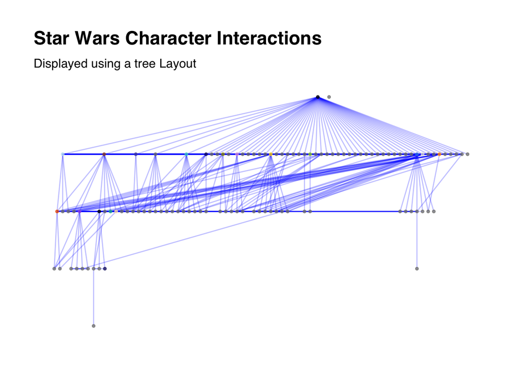

**- Plot using** `Multidimensional Scaling` **layout**

- The `mds`layout produced a visually appealing graph, but there is a large cluster of nodes in one region, making it difficult to extract information from the visualization.

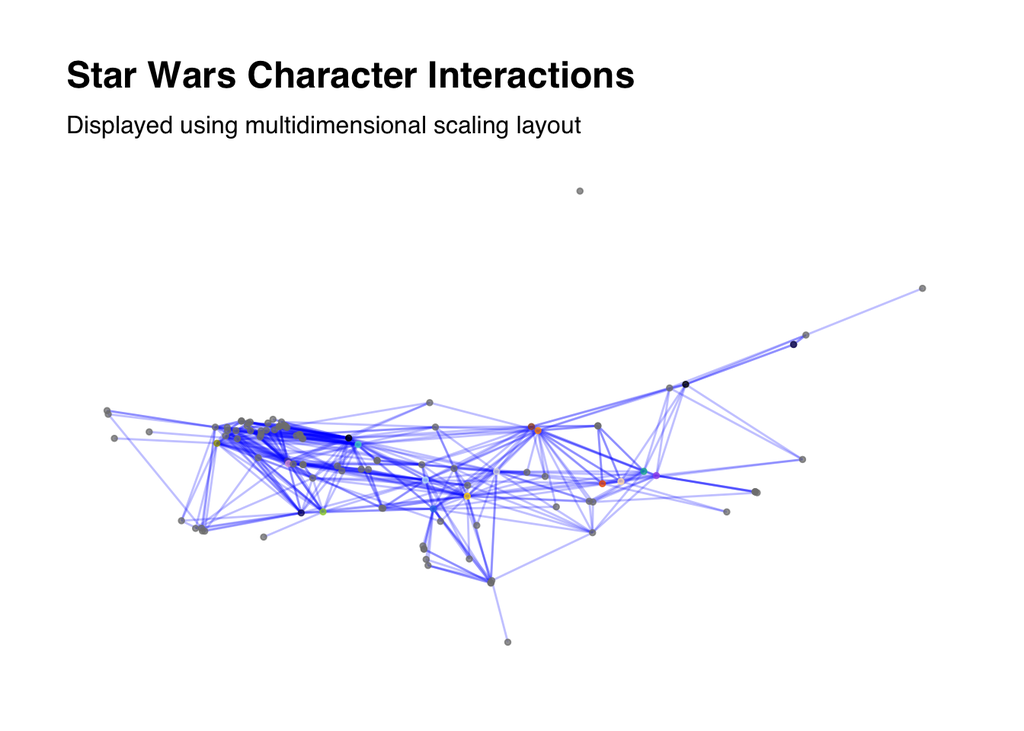

**- Plot using** `Kamada-Kawai` **layout**

- The `kk` layout created a plot that was visually appealing, and highlighted potential hubs, as well as nodes on the periphery.

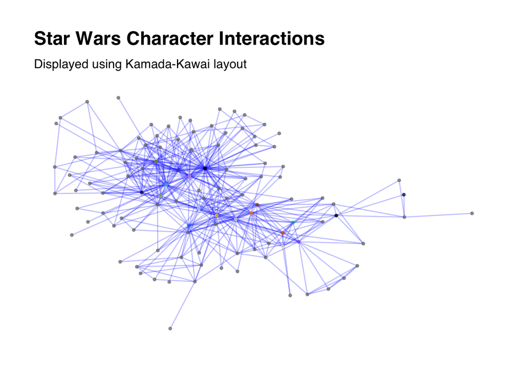

**3. Create a data.frame that contains eccentricity, betweenness, degree, transitivity, eigen centrality, and hub score for your network. You need to look up the documentation for the last two statistics in Help. Note that both eigen centrality and hub score return three lists and you need to access one of them. Make sure that you make the appropriate changes to the code. Do not include your code or its output in your report.**

- **Statistics for the network, including** `eccentricity`, `betweenness`, `degree`, `Transitivity`, `Eigen Centrality`, and `Hub Score`.

**4. Create a data.frame that includes the average degree, maximum degree, diameter, average clustering coefficient, average betweenness, average eigen centrality, and average hub score for your network. Include the output in your report but not your code. Do you notice anything interesting in this data.frame? Is this observation you are making also true when you look at the data.frame in Question 3?**

- **Metrics for the network, including** Avgerage Degree `[ADEG]`, `Max Degree`, `Proportion`, `Diameter`, `Radius`, Average clustering Coefficient `[ACC]`, Average betweenness `[ABT]`, Average Eigen Centrality `[AEC]`, and Average Hub Score `[AHS]`
  - The Average Degree of the graph was 8, which was suprising, as the values in the `head()` and `tail()` of the dataframe fluctuated between 4-6.

  ```
  ## # A tibble: 1 × 8
  ##    ADEG delta  diam radius   ACC   ABT   AEC   AHS
  ##   <dbl> <dbl> <dbl>  <dbl> <dbl> <dbl> <dbl> <dbl>
  ## 1     8    52     6      0 0.351  87.0 0.201 0.201
  ```

**5. Find the average distance in your network and create the plot for the distribution of distance in this network. What do you notice about this plot? Describe your observations in at most 50 words. Include your answer and the plot in your report, but not your code or other outputs.**

- **Average Distance in the network**
  - The average distance in the network is `2.610008`. This along with the plot reveals that the network is relatively dense, needing only 2.61 edges on average to connect two characters.

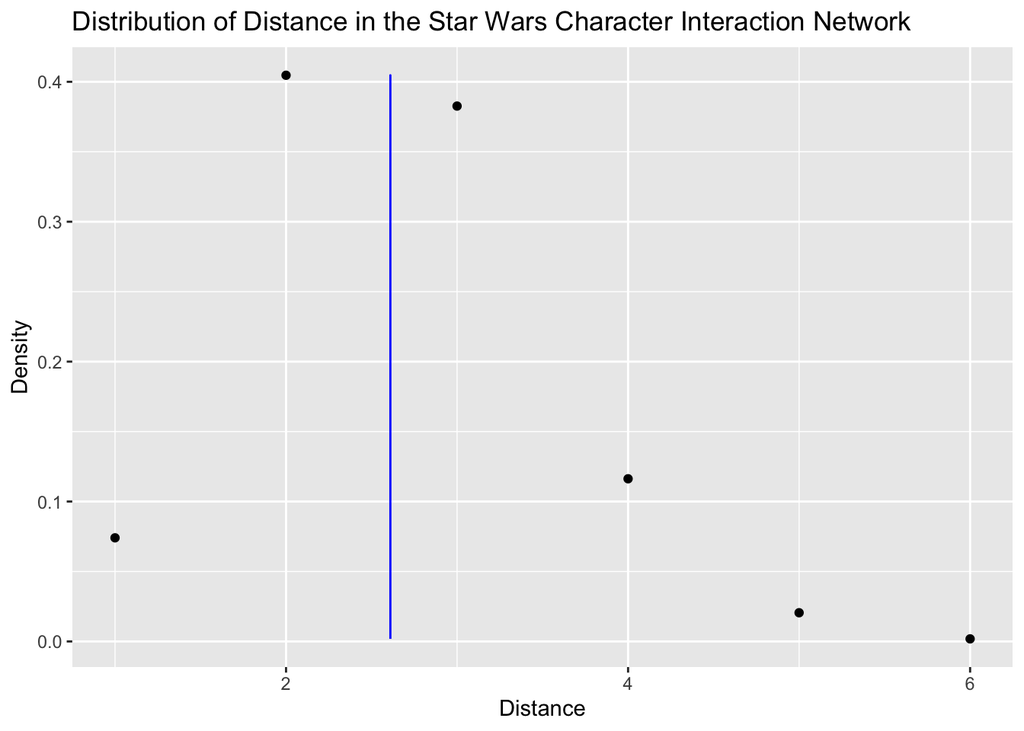

**6. Create the plot for the degree distribution in your network. What do you notice about this plot? Describe your observations in at most 25 words. Include your answer and one plot in your report, but not your code or other outputs.**

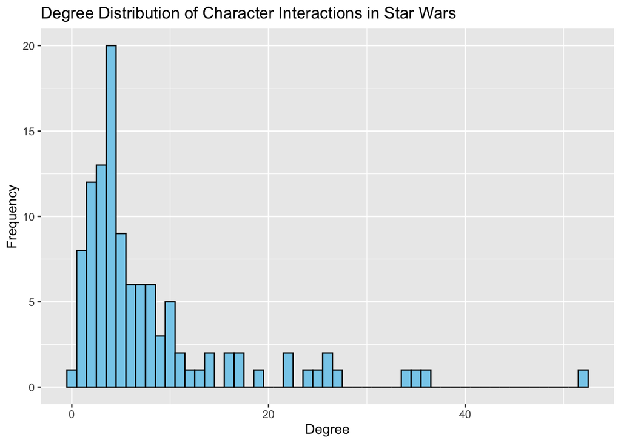

**7. Based on Question 6, do you think that the degree distribution follows a power law in your network? In other words, is this is a scale-free network? If so, find its degree exponent.**

**8. Create a plot (using dots rather histograms) containing both the degree distribution for your network (use blue) and the Poisson distribution with the correct parameter (use red). Include the plot in your report, but not your code.**

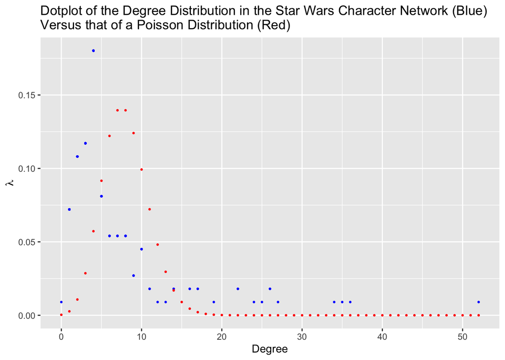

**9. Create a plot that visualizes the average of clustering coefficients based on the degree in your network. Is the average clustering coefficient matches what the Erdos-R ́enyi model predicts? Include your answer and one plot in your report, but not your code or other outputs.**

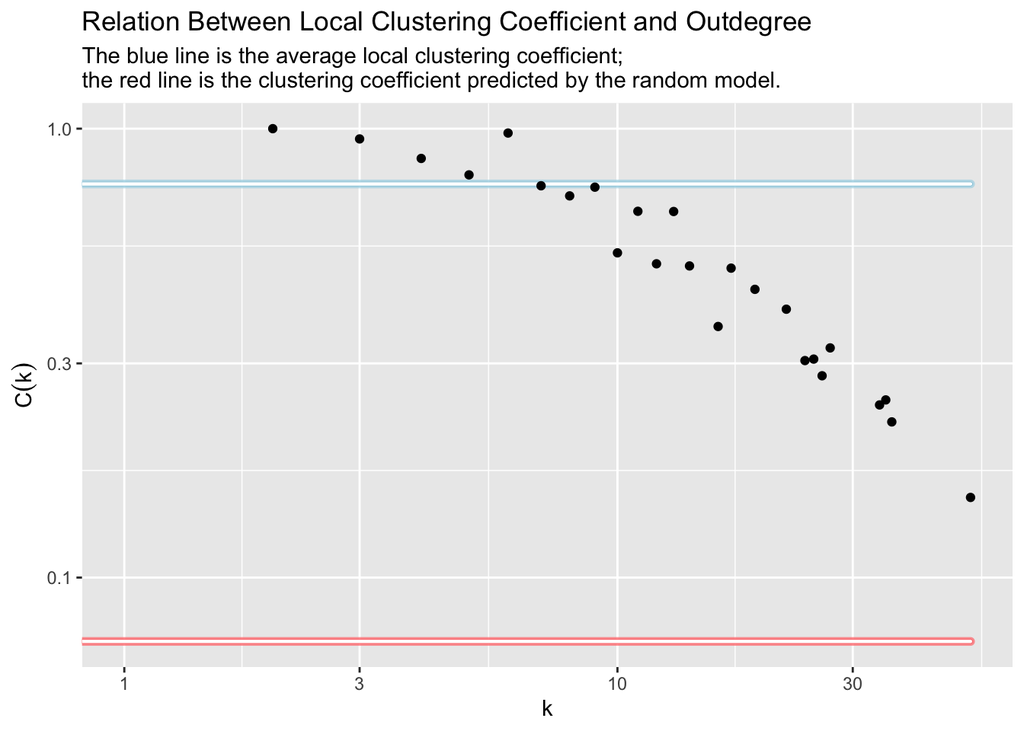

**10. Create a plot that visualizes the relationship between betweenness and degree in your network. What do you notice about this plot? Describe your observations in at most 50 words. Include your answer and the plot in your report, but not your code or other outputs.**

- The plot of the relationship between betweenness and degree in my network revealed that as the degree of a node increases, so does it’s betweenness centrality. This is expected as nodes with high betweenness, are often hubs, and hubs often have higher degrees.

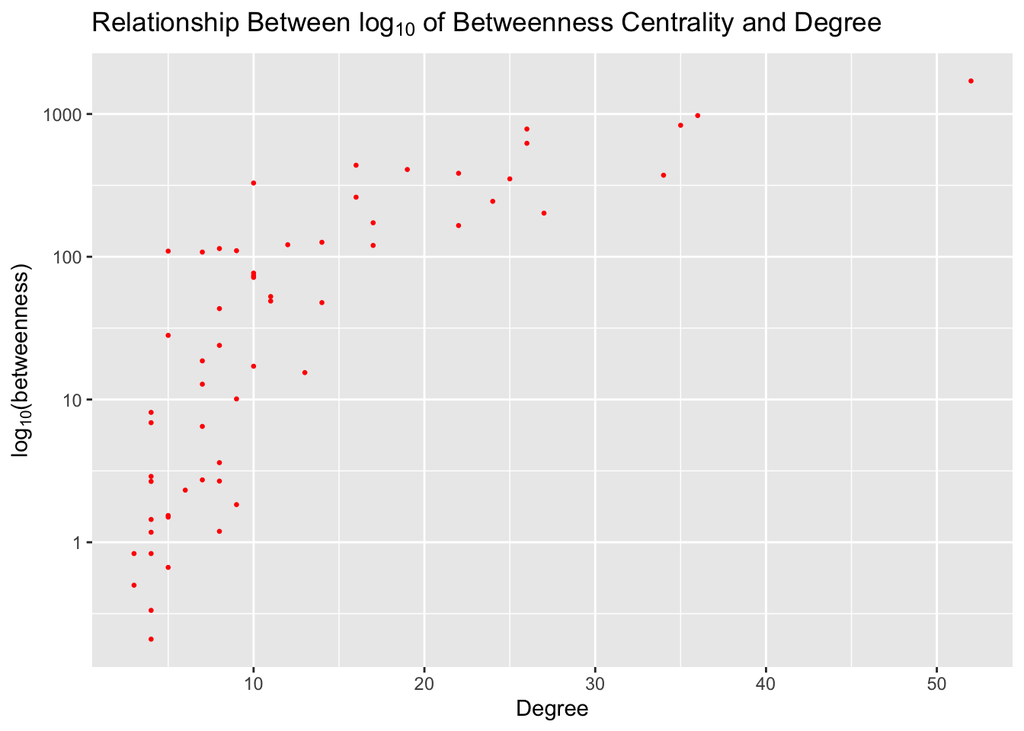

**11. Create a plot that visualizes the relationship between eccentricity and degree in your network. What do you notice about this plot? Describe your observations in at most 50 words. Include your answer and the plot in your report, but not your code or other outputs.**

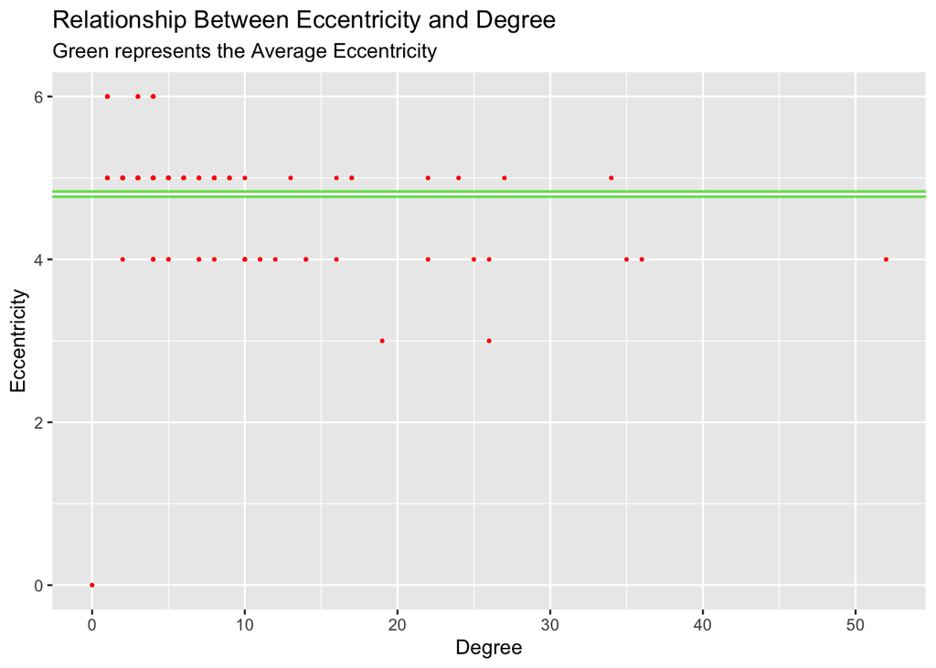

**12. Create a plot that visualizes the relationship between clustering and degree in your network. What do you notice about this plot? Describe your observations in at most 50 words. Include your answer and the plot in your report, but not your code or other outputs.**

- The plot that visualizes the relationship between clustering and degree in my network reveals that it is not similar to the Random Model.

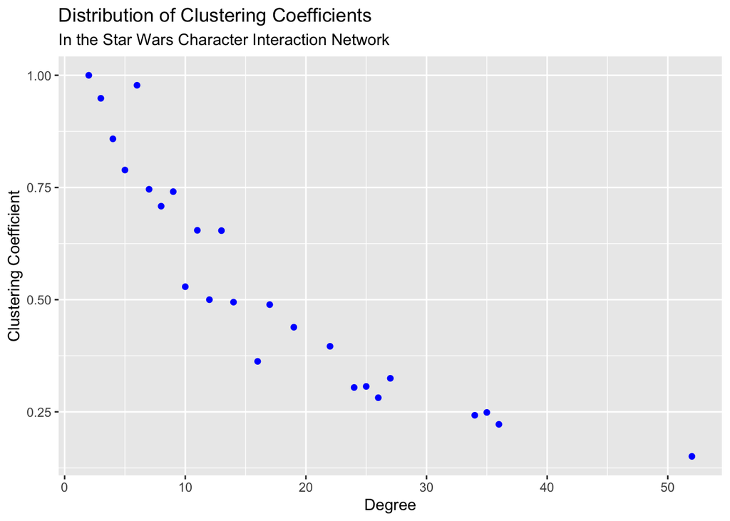

**13. Create a plot that visualizes the relationship between hub score and degree in your network. What do you notice about this plot? Describe your observations in at most 50 words. Include your answer and the plot in your report, but not your code or other outputs.**

- The plot that visualizes the relationship between hub score and degree in my network revealed that as a node’s degree increases, its hub score also increases, which is expected.

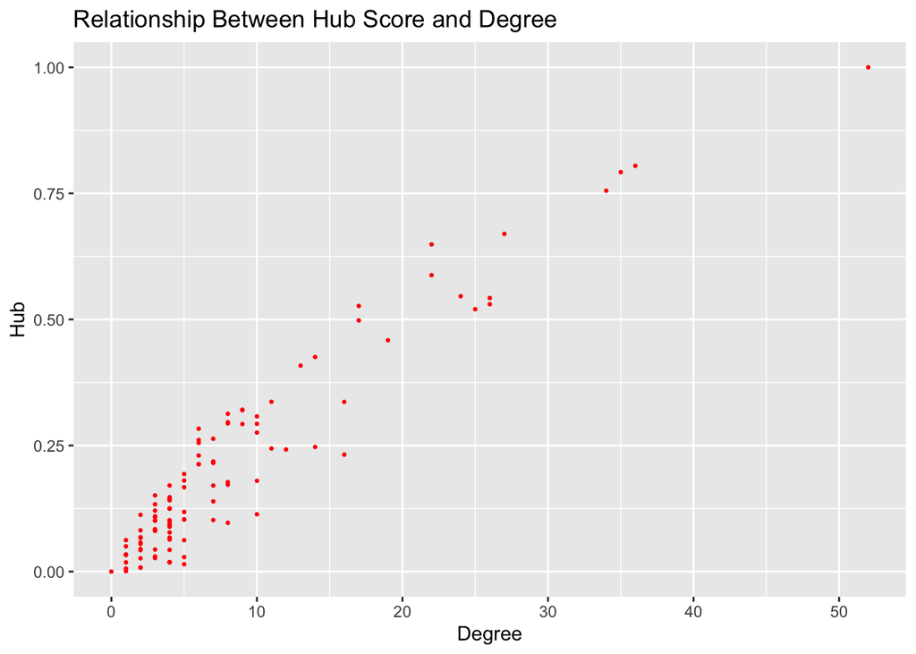